# Assignment 3

Edgar Chacón (edgarpedro.chacon01@estudiant.upf.edu) Judit Roca (judit.roca03@estudiant.upf.edu) Narine Fischer (narine.fischer01@estudiant.upf.edu)

Last update: 08 marzo, 2024

# 0. Introduction

This file corresponds to the third assignment of the “Data Mining and Data Integration in Biomedicine (**DMI**)” subject of the “Master in Bioinformatics for the health sciences” at “Pompeu Fabra University (**UPF**)”.  
Along this file, our comments will be highlighted in “purple”, in order to distinguish them from other statements.

## 0.1. Libraries

Libraries used in this R markdown.

```r
# ---------------------------------------------------------------------LIBRARIES

if (!require(readr)) install.packages("readr")
if (!require(dplyr)) install.packages("dplyr")
if (!require(car)) install.packages("car")
if (!require(leaps)) install.packages("leaps")
if (!require(tidymodels)) install.packages("tidymodels")
if (!require(corrplot)) install.packages("corrplot")
if (!require(class)) install.packages("class")
if (!require(gmodels)) install.packages("gmodels")
if (!require(rpart)) install.packages("rpart")
if (!require(rpart.plot)) install.packages("rpart.plot")
if (!require(pROC)) install.packages("pROC")
if (!require(randomForest)) install.packages("randomForest")
if (!require(caret)) install.packages("caret")
if (!require(ggcorrplot)) install.packages("ggcorrplot")
if (!require(glmnet)) install.packages("glmnet")
if (!require(class)) install.packages("class")
```

## 0.2. Colors

Color variables used in this R markdown.

```r
# ------------------------------------------------------------------------COLORS

color1 <- c("#8830A4")
color2 <- c("#90A430")
corplot_colors <- c("#8830A4", "white", "#90A430")
```

# 1. Exercise 1

#### [Stamey et al. 1989](https://www.auajournals.org/doi/10.1016/S0022-5347%2817%2941175-X) examined the correlation between the level of prostate-specific antigen (PSA) and a number of clinical measures in men who were about to receive a radical prostatectomy. PSA is a protein that is produced by the prostate gland. The higher a man’s PSA level, the more likely it is that he has prostate cancer.

#### Use the prostate cancer dataset, described here, to train a model that predicts log of prostate-specific antigen.

#### The variables are:

- log cancer volume (lcavol)
- log prostate weight (lweight)
- age
- log of the amount of benign prostatic hyperplasia (lbph)
- seminal vesicle invasion (svi)
- log of capsular penetration (lcp)
- Gleason score (gleason)
- percent of Gleason scores 4 or 5 (pgg45)

#### You can ignore column named “train” and do your own data splitting.

#### Do not forget to perform feature selection!

#### You can use as examples the [Linear Regression Lab](https://hastie.su.domains/ISLR2/Labs/Rmarkdown_Notebooks/Ch3-linreg-lab.html) and the section related to feature selection from [Lab: Linear Models and Regularization Methods](https://hastie.su.domains/ISLR2/Labs/Rmarkdown_Notebooks/Ch6-varselect-lab.html) from the book [An Introduction to Statistical Learning](https://www.statlearning.com/).

## 1.1. Data preparation

First, we upload our dataset of prostate cancer data.  
Additionally we use the `str()` function to display the data type and structure of each column of the dataset.

```r
# ---------------------------------------------PROSTATE CANCER DATASET UPLOADING

prostate_data <- read_delim("./data/prostate_data.txt", delim = "\t", escape_double = FALSE, show_col_types = FALSE, trim_ws = TRUE)
prostate_data <- as.data.frame(prostate_data)
str(prostate_data)
```

```
## 'data.frame':    97 obs. of  11 variables:
##  $ ...1   : num  1 2 3 4 5 6 7 8 9 10 ...
##  $ lcavol : num  -0.58 -0.994 -0.511 -1.204 0.751 ...
##  $ lweight: num  2.77 3.32 2.69 3.28 3.43 ...
##  $ age    : num  50 58 74 58 62 50 64 58 47 63 ...
##  $ lbph   : num  -1.39 -1.39 -1.39 -1.39 -1.39 ...
##  $ svi    : num  0 0 0 0 0 0 0 0 0 0 ...
##  $ lcp    : num  -1.39 -1.39 -1.39 -1.39 -1.39 ...
##  $ gleason: num  6 6 7 6 6 6 6 6 6 6 ...
##  $ pgg45  : num  0 0 20 0 0 0 0 0 0 0 ...
##  $ lpsa   : num  -0.431 -0.163 -0.163 -0.163 0.372 ...
##  $ train  : logi  TRUE TRUE TRUE TRUE TRUE TRUE ...
```

We delete the column named “…1” of the prostate dataset, as it only includes row numbers as information.

```r
# ---------------------------------------------PROSTATE CANCER DATASET CLEANNING

prostate_data <- prostate_data %>% dplyr::select(-(...1))
```

## 1.2. Model creation

Now, we create the subsets for training and testing the model.

```r
# ------------------------------------------TRAINING & TESTING DATASETS CREATION

training_dataset <- prostate_data %>% filter(train==TRUE) %>% select(-(train))

testing_dataset <- prostate_data%>% filter(train==FALSE)%>%select(-(train))
```

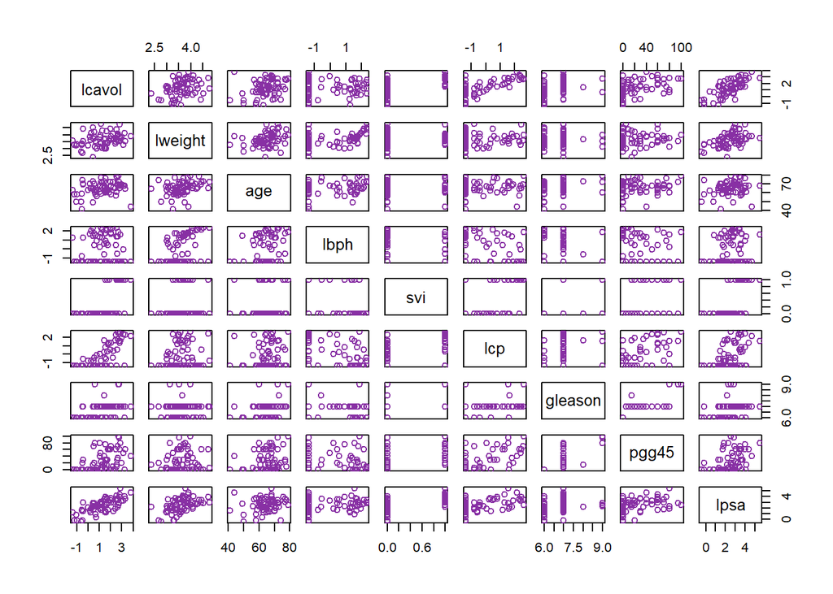

```r
# ------------------------------------------------------------CORRELATION MATRIX

pairs(training_dataset,col=color1)
```

```r
cor_training_dataset <- cor(training_dataset)

write.table(cor_training_dataset, file = "temp_cor_matrix.txt", sep = "\t", quote = FALSE)

cor_matrix <- read.table("temp_cor_matrix.txt", header = TRUE)
cor_matrix
```

```
##             lcavol    lweight       age        lbph        svi         lcp
## lcavol  1.00000000 0.30023199 0.2863243  0.06316772  0.5929491  0.69204308
## lweight 0.30023199 1.00000000 0.3167235  0.43704154  0.1810545  0.15682859
## age     0.28632427 0.31672347 1.0000000  0.28734645  0.1289023  0.17295140
## lbph    0.06316772 0.43704154 0.2873464  1.00000000 -0.1391468 -0.08853456
## svi     0.59294913 0.18105448 0.1289023 -0.13914680  1.0000000  0.67124021
## lcp     0.69204308 0.15682859 0.1729514 -0.08853456  0.6712402  1.00000000
## gleason 0.42641407 0.02355821 0.3659151  0.03299215  0.3068754  0.47643684
## pgg45   0.48316136 0.07416632 0.2758057 -0.03040382  0.4813577  0.66253335
## lpsa    0.73315515 0.48521519 0.2276424  0.26293763  0.5568864  0.48920320
##            gleason       pgg45      lpsa
## lcavol  0.42641407  0.48316136 0.7331551
## lweight 0.02355821  0.07416632 0.4852152
## age     0.36591512  0.27580573 0.2276424
## lbph    0.03299215 -0.03040382 0.2629376
## svi     0.30687537  0.48135774 0.5568864
## lcp     0.47643684  0.66253335 0.4892032
## gleason 1.00000000  0.75705650 0.3424278
## pgg45   0.75705650  1.00000000 0.4480480
## lpsa    0.34242781  0.44804795 1.0000000
```

```r
file.remove("temp_cor_matrix.txt")
```

```
## [1] TRUE
```

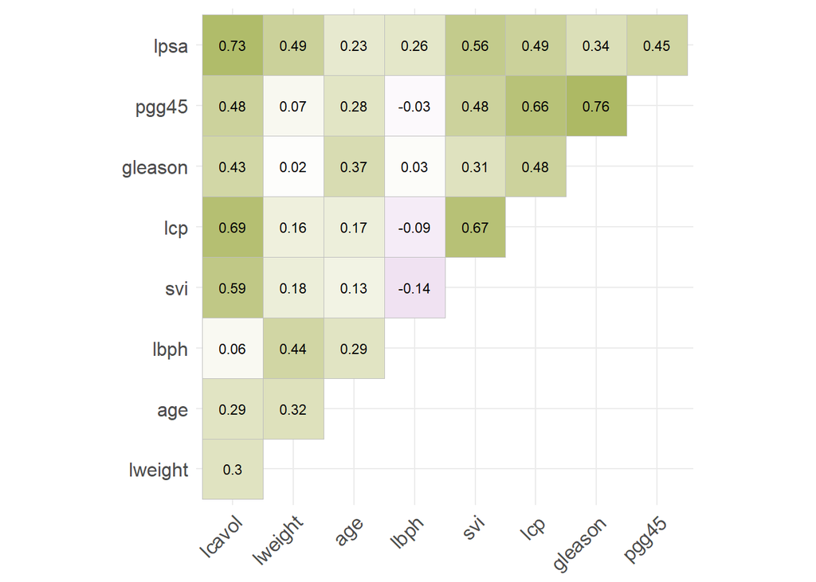

```r
# --------------------------------------------------------------CORRELATION PLOT

corr <- round(cor(training_dataset, use="complete.obs"), 2)
options(repr.plot.width=14, repr.plot.height=14)
ggcorrplot(corr, lab = TRUE, colors = corplot_colors,
           show.legend = F, outline.color = "gray", type = "upper", #hc.order = T,
           lab_size = 3, sig.level = .2) +
  labs(fill = "Correlation")
```

As we can see, there are several important correlations between variables such as `lcavol` with `lpsa` or `gleason` with `pgg45` (both with correlation values over 70%).  
Now, we define the training predictors to train our model to be able to predict `lpsa`.

```r
# ---------------------------------------------SETTING PREDICTORS & DATA SCALING

training_predictors <- prostate_data %>% filter(train==TRUE)%>%select(-c(train, lpsa))

testing_predictors <- prostate_data %>% filter(train==FALSE)%>%select(-c(train, lpsa))

training_predictors_scale <- as.data.frame(scale(training_predictors))
```

Once the data is scaled, we can add the `lpsa` values in order to create the machine learning model.

```r
# ----------------------------------------REDEFINING THE PROSTATE CANCER DATASET

training_dataset <- data.frame(training_dataset$lpsa,training_predictors_scale)

testing_predictors_scale <- as.data.frame(scale(testing_predictors))

testing_dataset <- data.frame(testing_dataset$lpsa,testing_predictors_scale)
```

## 1.3. Multiple linear regression model

To fit a multiple linear regression model we use least squares, using the `lm()` function.  
Then, summarized the data to obtain the regression coefficients for all the predictors.

```r
# ---------------------------------------------MULTIPLE LINEAR REGRESION MODEL 1

lm.fit <- lm(training_dataset.lpsa ~ . , data = training_dataset)

summary(lm.fit)
```

```
##
## Call:
## lm(formula = training_dataset.lpsa ~ ., data = training_dataset)
##
## Residuals:
##      Min       1Q   Median       3Q      Max
## -1.64870 -0.34147 -0.05424  0.44941  1.48675
##
## Coefficients:
##             Estimate Std. Error t value Pr(>|t|)
## (Intercept)  2.45235    0.08702  28.182  < 2e-16 ***
## lcavol       0.71641    0.13350   5.366 1.47e-06 ***
## lweight      0.29264    0.10638   2.751  0.00792 **
## age         -0.14255    0.10212  -1.396  0.16806
## lbph         0.21201    0.10312   2.056  0.04431 *
## svi          0.30962    0.12539   2.469  0.01651 *
## lcp         -0.28901    0.15480  -1.867  0.06697 .
## gleason     -0.02091    0.14258  -0.147  0.88389
## pgg45        0.27735    0.15959   1.738  0.08755 .
## ---
## Signif. codes:  0 '***' 0.001 '**' 0.01 '*' 0.05 '.' 0.1 ' ' 1
##
## Residual standard error: 0.7123 on 58 degrees of freedom
## Multiple R-squared:  0.6944, Adjusted R-squared:  0.6522
## F-statistic: 16.47 on 8 and 58 DF,  p-value: 2.042e-12
```

We generate the residuals plot for this model.

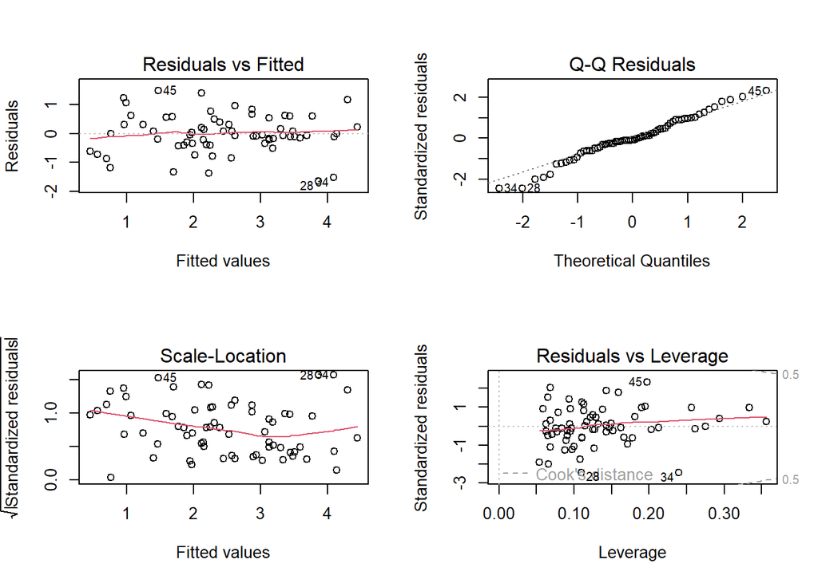

```r
# -------------------------------------------------------RESIDUALS PLOTS MODEL 1

par(mfrow = c(2, 2))
plot(lm.fit)
```

In order to calculate the Residual Sum of Squares (RSS) for the training dataset it is used the predict function.

```r
# --------------------------------------------------------SUM OF SQUARES MODEL 1

predictions <- predict(lm.fit, newdata=data.frame(training_dataset))

Res_sum_sq_1 <- sum((predictions-training_dataset$training_dataset.lpsa)^2)
```

In order to have a better prediction of `lpsa` we generate a new model with less variables, the ones that were significant in the previous model : `lcavol`, `lweight`, `lbph` and `svi`.

```r
# -----------------MODEL REDUCED (MODEL 2) INCLUDING ONLY SIGNIFICANT PREDICTORS

lm.fit_reduced <- lm(training_dataset.lpsa~lcavol+lweight+lbph+svi,data=training_dataset)

summary(lm.fit_reduced)
```

```
##
## Call:
## lm(formula = training_dataset.lpsa ~ lcavol + lweight + lbph +
##     svi, data = training_dataset)
##
## Residuals:
##     Min      1Q  Median      3Q     Max
## -1.8709 -0.3903 -0.0172  0.5676  1.4227
##
## Coefficients:
##             Estimate Std. Error t value Pr(>|t|)
## (Intercept)  2.45235    0.08888  27.592  < 2e-16 ***
## lcavol       0.62816    0.11502   5.461 8.85e-07 ***
## lweight      0.25681    0.10519   2.441   0.0175 *
## lbph         0.20493    0.10306   1.988   0.0512 .
## svi          0.28217    0.11475   2.459   0.0167 *
## ---
## Signif. codes:  0 '***' 0.001 '**' 0.01 '*' 0.05 '.' 0.1 ' ' 1
##
## Residual standard error: 0.7275 on 62 degrees of freedom
## Multiple R-squared:  0.6592, Adjusted R-squared:  0.6372
## F-statistic: 29.98 on 4 and 62 DF,  p-value: 6.911e-14
```

We generate the residuals plot for the reduced model.

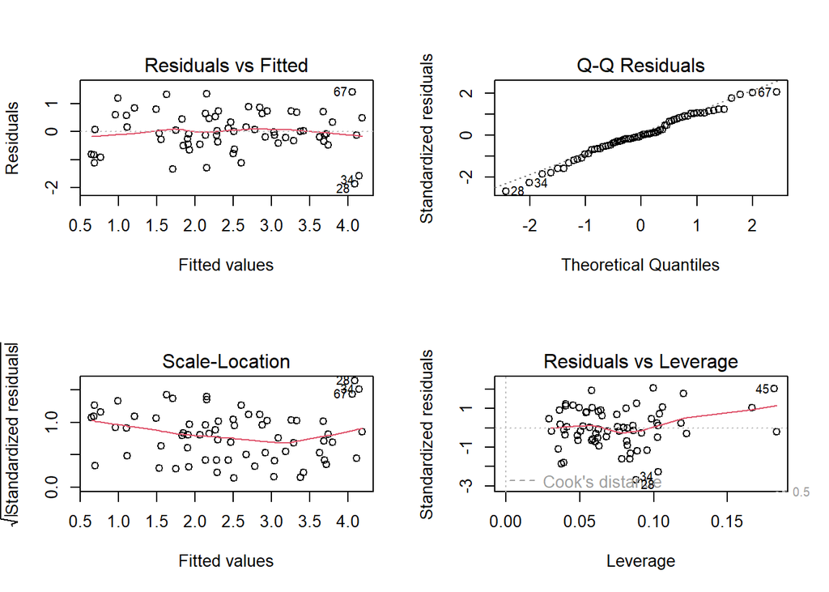

```r
# -------------------------------------------------------RESIDUALS PLOTS MODEL 2

par(mfrow = c(2, 2))
plot(lm.fit_reduced)
```

Predictions are generated using the linear model reduced on the subset “training_dataset”.  
The Residual Sum of Squares (RSS) is also calculated by comparing the predicted values with the actual values from the training data (measuring the difference between the predicted and actual values, squared and summed).

```r
# --------------------------------------------------------SUM OF SQUARES MODEL 2

predictions_reduced <- predict(lm.fit_reduced, newdata = data.frame(training_dataset))

Res_sum_sq_0 <- sum((predictions_reduced-training_dataset$training_dataset.lpsa)^2)

print(paste("RSS of model 2 is:", Res_sum_sq_0))
```

```
## [1] "RSS of model 2 is: 32.8149947488156"
```

```r
print(paste("RSS of model 1 was:", Res_sum_sq_1))
```

```
## [1] "RSS of model 1 was: 29.4263844599084"
```

Finally we perform an ANOVA test to compare both models.

```r
# ---------------------------------------------COMPARISON BETWEEN MODELS (ANOVA)

anova_result <- anova(lm.fit_reduced, lm.fit)
print(anova_result)
```

```
## Analysis of Variance Table
##
## Model 1: training_dataset.lpsa ~ lcavol + lweight + lbph + svi
## Model 2: training_dataset.lpsa ~ lcavol + lweight + age + lbph + svi +
##     lcp + gleason + pgg45
##   Res.Df    RSS Df Sum of Sq      F Pr(>F)
## 1     62 32.815
## 2     58 29.426  4    3.3886 1.6698 0.1693
```

The p-value obtained is 0.1693, we might not have enough evidence to reject the null hypothesis. Therefore, we cannot reject the smaller reduced model.  
The next step is working with the reduced model.

```r
# ---------------------------------------------------------------------------RSS

test_prediction <- predict(lm.fit_reduced,newdata=data.frame(testing_dataset))

Res_sum_sq_test <- sum((test_prediction-testing_dataset$testing_dataset.lpsa)^2)

cat("RSS on test data:", Res_sum_sq_test, "\n")
```

```
## RSS on test data: 14.68521
```

Finally, we plot a graph comparing the predicted `lpsa` values with the actual values.

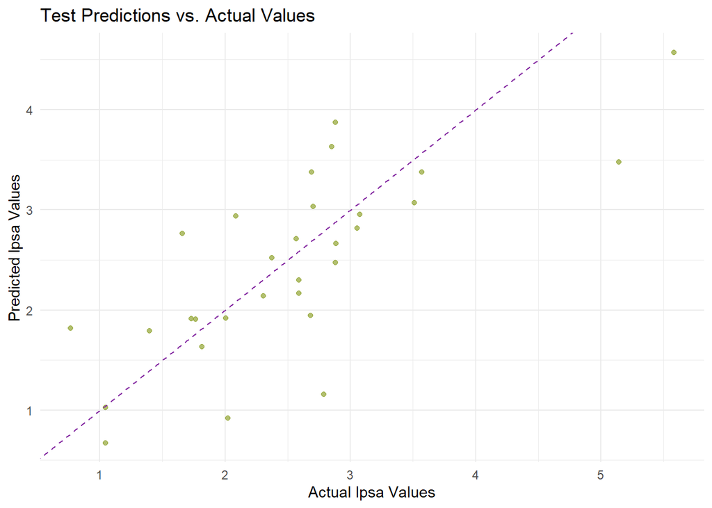

```r
# ---------------------------------------TESTING THE MODEL USING THE REDUCED ONE

comparison_data <- data.frame(Actual = testing_dataset$testing_dataset.lpsa, Predicted = test_prediction)

ggplot(comparison_data, aes(x = Actual, y = Predicted)) +
  geom_point(color = color2, alpha = 0.7) +
  geom_abline(intercept = 0, slope = 1, linetype = "dashed", color = color1) +
  labs(title = "Test Predictions vs. Actual Values",
       x = "Actual lpsa Values",
       y = "Predicted lpsa Values") +
  theme_minimal()
```

So, we can conclude that our predicted values are majorly similar to the actual ones because the dots in the graph are near the central line.

# 2. Exercise 2

#### Use the breast cancer dataset to train a model that predicts whether a future tumor image (with unknown diagnosis) is a benign or malignant tumor.

#### Try different machine learning algorithms such as:

- KNNs
- Decision trees
- Random forest
- Logistic Regression

#### The breast cancer dataset contains digitized breast cancer image features, and was created by [Dr. William H. Wolberg, W. Nick Street, and Olvi L. Mangasarian](https://archive.ics.uci.edu/ml/datasets/Breast+Cancer+Wisconsin+%28Diagnostic%29). Each row in the data set represents an image of a tumor sample, including the diagnosis (benign or malignant) and several other measurements (nucleus texture, perimeter, area, and more). Diagnosis for each image was conducted by physicians.

#### Do not forget to perform hyperparameter tuning!

#### You can use as a guide the analysis of this dataset included in the [chapter 5](https://datasciencebook.ca/classification1.html) of the Data Science, A First Introduction Book.

#### Additionally, for further information and ideas, you can check [this post](https://www.rebeccabarter.com/blog/2020-03-25_machine_learning/).

## 2.1. Data preparation

First of all, we upload our dataset of breast cancer data.  
Additionally we use the `str()` function to display the data type and structure of each column of the dataset.

```r
# ------------------------------------------------------BREAST DATASET UPLOADING

breast_data <- read_delim("./data/breat_cancer_data.csv", delim = ",", escape_double = FALSE, show_col_types = FALSE, trim_ws = TRUE)
breast_data <- as.data.frame(breast_data)
str(breast_data)
```

```
## 'data.frame':    568 obs. of  33 variables:
##  $ id                     : num  842302 842517 84300903 84348301 84358402 ...
##  $ diagnosis              : chr  "M" "M" "M" "M" ...
##  $ radius_mean            : num  18 20.6 19.7 11.4 20.3 ...
##  $ texture_mean           : num  10.4 17.8 21.2 20.4 14.3 ...
##  $ perimeter_mean         : num  122.8 132.9 130 77.6 135.1 ...
##  $ area_mean              : num  1001 1326 1203 386 1297 ...
##  $ smoothness_mean        : num  0.1184 0.0847 0.1096 0.1425 0.1003 ...
##  $ compactness_mean       : num  0.2776 0.0786 0.1599 0.2839 0.1328 ...
##  $ concavity_mean         : num  0.3001 0.0869 0.1974 0.2414 0.198 ...
##  $ concave points_mean    : num  0.1471 0.0702 0.1279 0.1052 0.1043 ...
##  $ symmetry_mean          : num  0.242 0.181 0.207 0.26 0.181 ...
##  $ fractal_dimension_mean : num  0.0787 0.0567 0.06 0.0974 0.0588 ...
##  $ radius_se              : num  1.095 0.543 0.746 0.496 0.757 ...
##  $ texture_se             : num  0.905 0.734 0.787 1.156 0.781 ...
```

[output cut: 19 more lines]

We delete the last column of the dataset because no information is included and it generated parsing issues.

```r
# -------------------------------------------------------------DATASET CLEANNING

breast_data <- breast_data[, !colnames(breast_data) %in% "...33"]
```

We then fix some column names in order to not contain spaces.

```r
# --------------------------------------------------------DATASET COLNAME FIXING

colnames(breast_data) <- sub(" ", "_", colnames(breast_data))
```

We generate a table with the content of the diagnosis column. The variable diagnosis is of particular interest because it is the outcome we want to predict. This feature indicates whether the example is from a benign or malignant mass.

```r
# -------------------------------------------------------DIAGNOSIS CONTENT TABLE

table(breast_data$diagnosis)
```

```
##
##   B   M
## 356 212
```

The table generated indicates that 356 masses are benign while 212 are malignant.  
We recode the diagnosis variable, because many machine learning classifiers require it to be a factor.  
Also, we give to the “`B`” and “`M`” values their complete label name.

```r
# ------------------------------------------------------RECODED DIAGNOSIS COLUMN

breast_data$diagnosis <- factor(breast_data$diagnosis, levels = c("B", "M"),
labels = c("Benign", "Malignant"))
round(prop.table(table(breast_data$diagnosis)) * 100, digits = 1)
```

```
##
##    Benign Malignant
##      62.7      37.3
```

We then show the counts of the Diagnosis column as a plot.

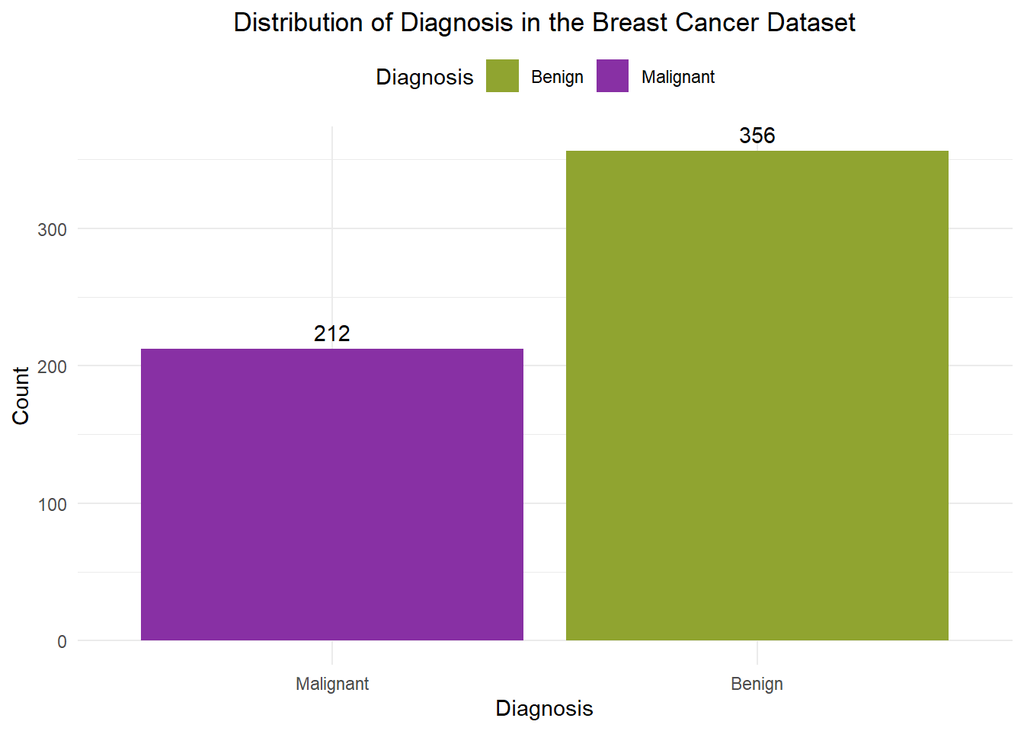

```r
# ----------------------------------------------------------------DIAGNOSIS PLOT

values <- c("Malignant", "Benign")

ggplot(breast_data, aes(x = factor(diagnosis, levels = values), fill = diagnosis)) +
  geom_bar(position = "dodge") +
  scale_fill_manual(values = c(color2, color1), name = "Diagnosis") +  # Added legend title
  ggtitle("Distribution of Diagnosis in the Breast Cancer Dataset") +
  theme_minimal() +
  geom_text(stat = "count", aes(label = after_stat(count)), position = position_dodge(width = 0.9), vjust = -0.5, color = "black") +
  scale_x_discrete(labels = values) +
  labs(x = "Diagnosis", y = "Count") +  # Used labs() to set x and y axis labels
  theme(legend.position = "top", plot.title = element_text(hjust = 0.5))
```

Looking at the output tables and figure, we can see that we have 62.7 percent of benign masses (n=356) and 37.3 percent of malignant masses (n=212).  
Now, we set the rownames as the content of the `column id`, and delete this column later on. Also, we generate a summary of the `diagnosis` column and the numeric data (the rest of columns that are not `diagnosis`).

```r
# ----------------------------------------------------BREAST CANCER DATA SUMMARY

rownames(breast_data) <- breast_data$id
breast_data <- breast_data[, -which(names(breast_data) == "id")]

summary(breast_data)
```

```
##      diagnosis    radius_mean      texture_mean   perimeter_mean
##  Benign   :356   Min.   : 6.981   Min.   : 9.71   Min.   : 43.79
##  Malignant:212   1st Qu.:11.707   1st Qu.:16.17   1st Qu.: 75.20
##                  Median :13.375   Median :18.84   Median : 86.29
##                  Mean   :14.139   Mean   :19.28   Mean   : 92.05
##                  3rd Qu.:15.797   3rd Qu.:21.79   3rd Qu.:104.15
##                  Max.   :28.110   Max.   :39.28   Max.   :188.50
##    area_mean      smoothness_mean   compactness_mean  concavity_mean
##  Min.   : 143.5   Min.   :0.06251   Min.   :0.01938   Min.   :0.00000
##  1st Qu.: 420.3   1st Qu.:0.08640   1st Qu.:0.06517   1st Qu.:0.02958
##  Median : 551.4   Median :0.09589   Median :0.09312   Median :0.06155
##  Mean   : 655.7   Mean   :0.09644   Mean   :0.10445   Mean   :0.08896
##  3rd Qu.: 784.1   3rd Qu.:0.10533   3rd Qu.:0.13043   3rd Qu.:0.13100
##  Max.   :2501.0   Max.   :0.16340   Max.   :0.34540   Max.   :0.42680
##  concave_points_mean symmetry_mean    fractal_dimension_mean   radius_se
##  Min.   :0.00000     Min.   :0.1060   Min.   :0.04996        Min.   :0.1115
##  1st Qu.:0.02035     1st Qu.:0.1620   1st Qu.:0.05770        1st Qu.:0.2324
##  Median :0.03360     Median :0.1792   Median :0.06155        Median :0.3240
##  Mean   :0.04901     Mean   :0.1812   Mean   :0.06280        Mean   :0.4052
##  3rd Qu.:0.07401     3rd Qu.:0.1957   3rd Qu.:0.06613        3rd Qu.:0.4798
##  Max.   :0.20120     Max.   :0.3040   Max.   :0.09744        Max.   :2.8730
##    texture_se      perimeter_se       area_se        smoothness_se
##  Min.   :0.3602   Min.   : 0.757   Min.   :  6.802   Min.   :0.001713
##  1st Qu.:0.8331   1st Qu.: 1.605   1st Qu.: 17.850   1st Qu.:0.005166
##  Median :1.1080   Median : 2.285   Median : 24.565   Median :0.006374
##  Mean   :1.2165   Mean   : 2.867   Mean   : 40.374   Mean   :0.007041
##  3rd Qu.:1.4743   3rd Qu.: 3.360   3rd Qu.: 45.237   3rd Qu.:0.008151
##  Max.   :4.8850   Max.   :21.980   Max.   :542.200   Max.   :0.031130
##  compactness_se      concavity_se     concave_points_se   symmetry_se
##  Min.   :0.002252   Min.   :0.00000   Min.   :0.000000   Min.   :0.007882
##  1st Qu.:0.013133   1st Qu.:0.01510   1st Qu.:0.007663   1st Qu.:0.015128
##  Median :0.020460   Median :0.02592   Median :0.010950   Median :0.018725
##  Mean   :0.025515   Mean   :0.03195   Mean   :0.011817   Mean   :0.020531
##  3rd Qu.:0.032455   3rd Qu.:0.04212   3rd Qu.:0.014730   3rd Qu.:0.023398
##  Max.   :0.135400   Max.   :0.39600   Max.   :0.052790   Max.   :0.078950
##  fractal_dimension_se  radius_worst   texture_worst   perimeter_worst
##  Min.   :0.0008948    Min.   : 7.93   Min.   :12.02   Min.   : 50.41
##  1st Qu.:0.0022445    1st Qu.:13.03   1st Qu.:21.07   1st Qu.: 84.15
##  Median :0.0031955    Median :14.97   Median :25.41   Median : 97.67
##  Mean   :0.0037967    Mean   :16.28   Mean   :25.67   Mean   :107.35
##  3rd Qu.:0.0045585    3rd Qu.:18.80   3rd Qu.:29.68   3rd Qu.:125.53
##  Max.   :0.0298400    Max.   :36.04   Max.   :49.54   Max.   :251.20
##    area_worst     smoothness_worst  compactness_worst concavity_worst
##  Min.   : 185.2   Min.   :0.07117   Min.   :0.02729   Min.   :0.0000
##  1st Qu.: 515.7   1st Qu.:0.11660   1st Qu.:0.14758   1st Qu.:0.1159
##  Median : 686.5   Median :0.13135   Median :0.21300   Median :0.2275
##  Mean   : 881.7   Mean   :0.13244   Mean   :0.25460   Mean   :0.2727
##  3rd Qu.:1085.0   3rd Qu.:0.14602   3rd Qu.:0.33930   3rd Qu.:0.3835
##  Max.   :4254.0   Max.   :0.22260   Max.   :1.05800   Max.   :1.2520
##  concave_points_worst symmetry_worst   fractal_dimension_worst
##  Min.   :0.00000      Min.   :0.1565   Min.   :0.05504
##  1st Qu.:0.06497      1st Qu.:0.2504   1st Qu.:0.07147
##  Median :0.10002      Median :0.2821   Median :0.08005
##  Mean   :0.11481      Mean   :0.2901   Mean   :0.08397
##  3rd Qu.:0.16168      3rd Qu.:0.3180   3rd Qu.:0.09208
##  Max.   :0.29100      Max.   :0.6638   Max.   :0.20750
```

We want to see the correlation between all independent variables.

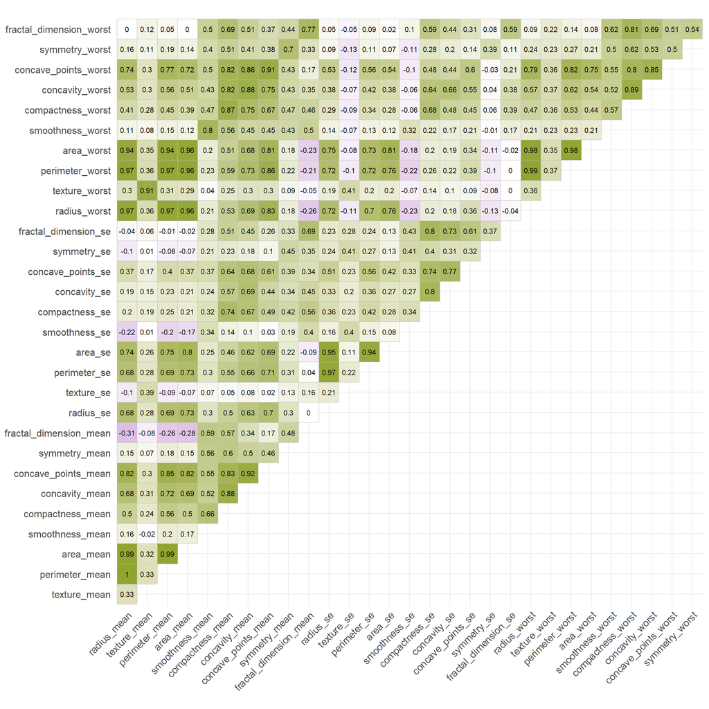

```r
# -------------------------------------------BREAST CANCER DATA CORRELATION PLOT

corr <- round(cor(breast_data[,-1], use="complete.obs"), 2)
options(repr.plot.width=14, repr.plot.height=14)
ggcorrplot(corr, lab = TRUE, colors = corplot_colors,
           show.legend = F, outline.color = "gray", type = "upper", #hc.order = T,
           lab_size = 3, sig.level = .2) +
  labs(fill = "Correlation")
```

As an example, we can see in this correlation plot that the `area`, `perimeter` and `radius` are very correlated between `worst` and `mean` and between each other inside `worst` and `mean`.  
But we want to make sure which are the most correlated variables to remove them in order to avoid multicollinearity.  
To do so, we check which variables are the most highly correlated.

```r
# ------------------------------------------CHECKING HIGHLY CORRELATED VARIABLES

multicollinearity <- subset (breast_data, select = -c(diagnosis))
multicollinearity_cor <- cor(multicollinearity)

highlyCorrelated = findCorrelation(multicollinearity_cor, cutoff=0.7)
highlyCorCol = colnames(multicollinearity) [highlyCorrelated]
highlyCorCol
```

```
##  [1] "concavity_mean"         "concave_points_mean"    "compactness_mean"
##  [4] "concave_points_worst"   "concavity_worst"        "perimeter_worst"
##  [7] "radius_worst"           "compactness_worst"      "perimeter_mean"
## [10] "area_worst"             "radius_mean"            "perimeter_se"
## [13] "radius_se"              "concave_points_se"      "area_se"
## [16] "compactness_se"         "concavity_se"           "smoothness_mean"
## [19] "symmetry_mean"          "fractal_dimension_mean" "texture_worst"
```

Those highly correlated variables will be removed from a dataset later on (Note from the future: it’s in the logistic regression dataset).  
For the data preparation and to create the training, test and validation datasets, the best results from empirical studies are obtained using 20-30 % of testing and validation data and 70-80 % of training data.  
For this study, we decided to adopt a strategy that involves using 10% of the entire dataset for validation.  
Subsequently, from the remaining 90% of the data, we further split it into 25% for testing data and 75% for training.  
This distribution aims to strike a balance between ensuring model robustness, allowing for comprehensive training, and evaluating performance on unseen data.

```r
# --------------------------------------------------------------DATA PREPARATION

# The following command sets the seed for the random number generator to ensure reproducibility.
set.seed(123)

# Generate a TRUE/FALSE vector for validation set
sample_validation <- sample(c(TRUE, FALSE), size = nrow(breast_data), replace = TRUE, prob = c(0.10, 0.90))
breast_data_validation <- breast_data[sample_validation,]

# The remaining data is used for training and testing
breast_data_test_training <- breast_data[!sample_validation,]


#It is generated a TRUE/FALSE vector in order to split the dataset into train and test samples.
sample <- sample(c(TRUE, FALSE), size = nrow(breast_data_test_training), replace = TRUE, prob = c(0.25, 0.75))
breast_data_train <- breast_data_test_training[!sample,]
breast_data_test <- breast_data_test_training[sample,]


#In order to train the KNN model, factor vectors are created to store the class labels previously generated.
breast_data_train_labels <- breast_data_test_training[!sample, 1]    #Extracting training data
breast_data_test_labels <- breast_data_test_training[sample, 1]  #Extracting test data
```

Now we normalize the numeric columns of the dataset.

```r
# ------------------------------------------------NORMALIZING BREAST CANCER DATA

normalize <- function(x) {
return ((x - min(x)) / (max(x) - min(x)))}   #creating a normalize() function

breast_data_train_norm <- as.data.frame(lapply(breast_data_train[2:31], normalize))
rownames(breast_data_train_norm) <- rownames(breast_data_train)

breast_data_test_norm <- as.data.frame(lapply(breast_data_test[2:31], normalize))
rownames(breast_data_test_norm) <- rownames(breast_data_test)

breast_data_validation_norm <- as.data.frame(lapply(breast_data_validation[2:31], normalize))
rownames(breast_data_validation_norm) <- rownames(breast_data_validation)
```

Once the data is normalized, the diagnosis column is re-included.

```r
# ------------------REINTRODUCTION OF DIAGNOSIS TO NORMALIZED BREAST CANCER DATA

breast_data_train_complete <- cbind(breast_data_train$diagnosis, breast_data_train_norm)
colnames(breast_data_train_complete)[1] <- "diagnosis"

breast_data_test_complete <- cbind(breast_data_test$diagnosis, breast_data_test_norm)
colnames(breast_data_test_complete)[1] <- "diagnosis"

breast_data_validation_complete <- cbind(breast_data_validation$diagnosis, breast_data_validation_norm)
colnames(breast_data_validation_complete)[1] <- "diagnosis"
```

## 2.2. KNN algorithm

We create the training, testing and validation datasets for the KNN algorithm. They are exactly the same datasets as the training, validation and test datasets previously generated, but with its name adapted to this section.

```r
# ------------------------------------------TRAIN & TEST KNN DATASET PREPARATION

breast_data_train_knn <- breast_data_train_complete
breast_data_test_knn <- breast_data_test_complete
breast_data_validation_knn <- breast_data_validation_complete
```

In order to perform KNN algorithm, it is used knn() function. As k integer (the hyperparameter of the KNN algorithm), indicating the number of nearest neighbors, it is used the result number from the best k generated by comparing 20 random k values. knn() function is returning a factor vector of predicted labels for each of the observations included in the test data, it is called “knn_prediction”.  
Then, it is performed an evaluation of the model generated.  
The model is evaluated by means of CrossTable() function which is included in gmodels library, it is using the best k generated.

```r
# ----------------------------------------KNN ALGORITHM, EVALUATION OF THE MODEL

#Set seed for reproducibility
set.seed(123)

# Specify the number of random k-values to try
num_random_k <- 20

# Create an empty data frame to store results
results_df <- data.frame(k_value = numeric(), AUC = numeric(), selected = logical())

# Iterate over random k-values
for (i in 1:num_random_k) {
  # Generate a random value for k (adjust the range as needed)
  random_k <- sample(2:30, 1)

  # Train KNN model with the random k value
  knn_prediction <- knn(train = breast_data_train_knn[, -1],
                        test = breast_data_test_knn[, -1],
                        cl = breast_data_train_knn$diagnosis,
                        k = random_k)

  # Evaluate model using performance metrics
  AUC_knn <- tryCatch(
    pROC::roc(as.numeric(breast_data_test_knn$diagnosis), as.numeric(knn_prediction)),
    error = function(e) {
      warning("Error calculating AUC for k =", random_k)
      return(NULL)
    }
  )

  # Store results in the data frame
  results_df <- rbind(results_df, data.frame(k_value = random_k,
                                              AUC = ifelse(!is.null(AUC_knn), AUC_knn$auc, NA),
                                              selected = NA))
}

# Choose the best k based on AUC
best_k <- results_df$k_value[which.max(results_df$AUC)]

# Update the 'selected' column
results_df$selected <- results_df$k_value == best_k

# Print the results data frame
print(results_df)
```

```
##    k_value       AUC selected
## 1       16 0.9464286    FALSE
## 2       15 0.9553571     TRUE
## 3        2 0.9321429    FALSE
## 4       23 0.9375000    FALSE
## 5       25 0.9464286    FALSE
## 6       15 0.9553571     TRUE
## 7        4 0.9553571    FALSE
## 8       11 0.9464286    FALSE
## 9       24 0.9464286    FALSE
## 10      26 0.9553571    FALSE
## 11      14 0.9464286    FALSE
## 12       7 0.9553571    FALSE
## 13       2 0.9482143    FALSE
## 14      17 0.9553571    FALSE
## 15       5 0.9553571    FALSE
## 16      15 0.9553571     TRUE
## 17      23 0.9375000    FALSE
## 18      21 0.9375000    FALSE
## 19      18 0.9553571    FALSE
## 20      30 0.9553571    FALSE
```

```r
# Print the best k
cat("Best k based on AUC:", best_k, "\n")
```

```
## Best k based on AUC: 15
```

```r
#Training KNN model with the best k value
best_knn_prediction <- knn(train = breast_data_train_knn[, -1],
                            test = breast_data_test_knn[, -1],
                            cl = breast_data_train_knn$diagnosis,
                            k = best_k)

#Creating a cross-table
cross_table_result <- CrossTable(x = breast_data_test_labels,
                                 y = best_knn_prediction,
                                 prop.chisq = FALSE)
```

```
##
##
##    Cell Contents
## |-------------------------|
## |                       N |
## |           N / Row Total |
## |           N / Col Total |
## |         N / Table Total |
## |-------------------------|
##
##
## Total Observations in Table:  126
##
##
##                         | best_knn_prediction
## breast_data_test_labels |    Benign | Malignant | Row Total |
## ------------------------|-----------|-----------|-----------|
##                  Benign |        70 |         0 |        70 |
##                         |     1.000 |     0.000 |     0.556 |
##                         |     0.933 |     0.000 |           |
##                         |     0.556 |     0.000 |           |
## ------------------------|-----------|-----------|-----------|
##               Malignant |         5 |        51 |        56 |
##                         |     0.089 |     0.911 |     0.444 |
##                         |     0.067 |     1.000 |           |
##                         |     0.040 |     0.405 |           |
## ------------------------|-----------|-----------|-----------|
##            Column Total |        75 |        51 |       126 |
##                         |     0.595 |     0.405 |           |
## ------------------------|-----------|-----------|-----------|
##
##
```

## 2.3. Decision Tree algorithm

```r
# -----------------------------------------TRAIN & TEST TREE DATASET PREPARATION

breast_data_train_tree <- breast_data_train_complete
breast_data_test_tree <- breast_data_test_complete
breast_data_validation_tree <- breast_data_validation_complete
```

```r
# -----------------------------------DECISION TREE ALGORITHM PARAMETER SELECTION

# Finding the ideal values for minsplit and maxdepth
AUC_train_besttree <- 0
AUC_test_besttree <- 0
best_tree_parameters <- data.frame(minsplit_para = NA, maxdepth_para = NA)

set.seed(3011)
tree_parameters <- data.frame(minsplit_para = floor(runif(10, 10, 60)),
                              maxdepth_para = floor(runif(10, 10, 30)))

# Create an empty data frame to store AUC values along with minsplit and maxdepth
AUC_tree <- data.frame(minsplit_para = numeric(), maxdepth_para = numeric(),
                        AUC_train_tree = numeric(), AUC_test_tree = numeric(),
                        selected = logical())

for(para_comb in 1:nrow(tree_parameters)){
  decision_tree <- rpart(diagnosis ~ .,  data = breast_data_train_tree,
                      control = rpart.control(minsplit = tree_parameters[para_comb, "minsplit_para"],
                                              maxdepth = tree_parameters[para_comb, "maxdepth_para"]))

  pred_train_tree <- as.numeric(predict(decision_tree, breast_data_train_tree, type='vector'))
  AUC_train_tree <- pROC::roc(as.numeric(breast_data_train_tree$diagnosis), pred_train_tree)

  pred_test_tree <- as.numeric(predict(decision_tree, breast_data_test_tree, type='vector'))
  AUC_test_tree <- pROC::roc(as.numeric(breast_data_test_tree$diagnosis), pred_test_tree)

  AUC_train_besttree <- ifelse(AUC_train_besttree > AUC_train_tree$auc, AUC_train_besttree, AUC_train_tree$auc)
  AUC_test_besttree <- ifelse(AUC_test_besttree > AUC_test_tree$auc, AUC_test_besttree, AUC_test_tree$auc)

  # Update best_tree_parameters if a better combination is found
  if (AUC_train_tree$auc == AUC_train_besttree && AUC_test_tree$auc == AUC_test_besttree) {
    best_tree_parameters$minsplit_para <- tree_parameters[para_comb, "minsplit_para"]
    best_tree_parameters$maxdepth_para <- tree_parameters[para_comb, "maxdepth_para"]
  }

  # Store minsplit, maxdepth, and AUC values in the AUC_tree data frame
  AUC_tree[para_comb, ] <- c(tree_parameters[para_comb, ],
                             round(AUC_train_tree$auc, 4),
                             round(AUC_test_tree$auc, 4),
                             selected = identical(best_tree_parameters, tree_parameters[para_comb, ]))
}

# Print the AUC_tree data frame with highlighting
print(AUC_tree)
```

```
##    minsplit_para maxdepth_para AUC_train_tree AUC_test_tree selected
## 1             22            18         0.9528        0.9589     TRUE
## 2             14            14         0.9528        0.9589    FALSE
## 3             10            15         0.9640        0.9607    FALSE
## 4             15            25         0.9528        0.9589    FALSE
## 5             29            28         0.9505        0.9589    FALSE
## 6             42            10         0.9500        0.9393    FALSE
## 7             59            25         0.9500        0.9393    FALSE
## 8             11            15         0.9528        0.9589    FALSE
## 9             15            11         0.9528        0.9589    FALSE
## 10            46            26         0.9500        0.9393    FALSE
```

Now we use the best hyperparameters found to build the final decision tree model.

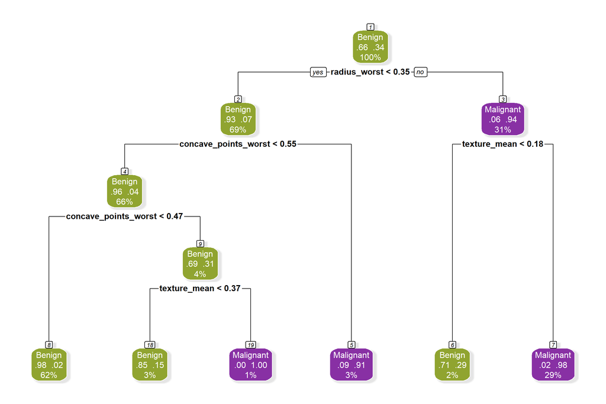

```r
# -------------------------------------------------------DECISION TREE ALGORITHM



# Using the best parameters to train the final decision tree
final_decision_tree <- rpart(diagnosis ~ ., data = breast_data_train_tree,
                             control = rpart.control(minsplit = best_tree_parameters$minsplit_para,
                                                     maxdepth = best_tree_parameters$maxdepth_para))

# Visualizing the final decision tree
#prp(final_decision_tree)
box_colors <- ifelse(final_decision_tree$frame$yval == 1, color2, color1)

rpart.plot(final_decision_tree, extra = 104, nn = TRUE, shadow.col="gray90", box.col = box_colors, col = "white")
```

## 2.4. Random Forest algorithm

We create the training, testing and validation datasets for the Random Forest algorithm. They are exactly the same datasets as the training, validation and test datasets previously generated, but with its name adapted to this section.

```r
# --------------------------------TRAIN & TEST RANDOM FOREST DATASET PREPARATION

breast_data_train_forest <- breast_data_train_complete
breast_data_test_forest <- breast_data_test_complete
breast_data_validation_forest <- breast_data_validation_complete
```

```r
# -----------------------------------RANDOM FOREST ALGORITHM PARAMETER SELECTION

# Set seed for reproducibility
set.seed(3011)

# Initialize variables
AUC_train_bestforest <- 0
AUC_test_bestforest <- 0
best_forest_parameters <- data.frame(nodesize = NA, sampsize = NA, mtry = NA, ntree = NA)

# Create random combinations of rf_parameters
rf_parameters <- data.frame(nodesize = round(runif(10, 5, 20)),
                            sampsize = round(runif(10, 1, 400)),
                            mtry = round(runif(10, 1, 10)),
                            ntree = round(runif(10, 1, 400)))

# Create an empty data frame to store AUC values along with rf_parameters
AUC_forest <- data.frame(nodesize = numeric(), sampsize = numeric(),
                         mtry = numeric(), ntree = numeric(),
                         AUC_train_forest = numeric(), AUC_test_forest = numeric(),
                         selected = logical())

for (para_comb in 1:nrow(rf_parameters)) {
  # Build random forest model
  random_forest <- randomForest(diagnosis ~ ., data = breast_data_train_forest,
                                nodesize = rf_parameters[para_comb, "nodesize"],
                                sampsize = rf_parameters[para_comb, "sampsize"],
                                mtry = rf_parameters[para_comb, "mtry"],
                                ntree = rf_parameters[para_comb, "ntree"])

  # Predict on the training set
  pred_train_forest <- as.numeric(predict(random_forest, breast_data_train_forest, type='response'))
  AUC_train_forest <- pROC::roc(as.numeric(breast_data_train_forest$diagnosis), pred_train_forest)

  # Predict on the test set
  pred_test_forest <- as.numeric(predict(random_forest, breast_data_test_forest, type='response'))
  AUC_test_forest <- pROC::roc(as.numeric(breast_data_test_forest$diagnosis), pred_test_forest)

  # Update best_forest_parameters if a better combination is found
  if (AUC_train_forest$auc > AUC_train_bestforest && AUC_test_forest$auc > AUC_test_bestforest) {
    AUC_train_bestforest <- AUC_train_forest$auc
    AUC_test_bestforest <- AUC_test_forest$auc
    best_forest_parameters$nodesize <- rf_parameters[para_comb, "nodesize"]
    best_forest_parameters$sampsize <- rf_parameters[para_comb, "sampsize"]
    best_forest_parameters$mtry <- rf_parameters[para_comb, "mtry"]
    best_forest_parameters$ntree <- rf_parameters[para_comb, "ntree"]
  }

  # Store rf_parameters and AUC values in the AUC_forest data frame
  AUC_forest[para_comb, ] <- c(rf_parameters[para_comb, ],
                               round(AUC_train_forest$auc, 4),
                               round(AUC_test_forest$auc, 4),
                               selected = identical(best_forest_parameters, rf_parameters[para_comb, ]))
}

# Print the AUC_forest data frame with highlighting
print(AUC_forest)
```

```
##    nodesize sampsize mtry ntree AUC_train_forest AUC_test_forest selected
## 1         9      168    4   145           0.9642          0.9107     TRUE
## 2         6       86    8    71           0.9488          0.9286    FALSE
## 3         5      112   10   192           0.9622          0.9464    FALSE
## 4         7      313    9   326           0.9850          0.9643    FALSE
## 5        11      361    5   366           0.9774          0.9375    FALSE
## 6        15        3    7    37           0.8370          0.8625    FALSE
## 7        20      310   10   286           0.9680          0.9393    FALSE
## 8         5      109    7   264           0.9678          0.9464    FALSE
## 9         7       28    8   316           0.9338          0.9018    FALSE
## 10       16      330   10   354           0.9755          0.9214    FALSE
```

```r
# Print the best_forest_parameters
print(best_forest_parameters)
```

```
##   nodesize sampsize mtry ntree
## 1        7      313    9   326
```

Now we generate the random forest model using the best hyperparameters found in the previous section.

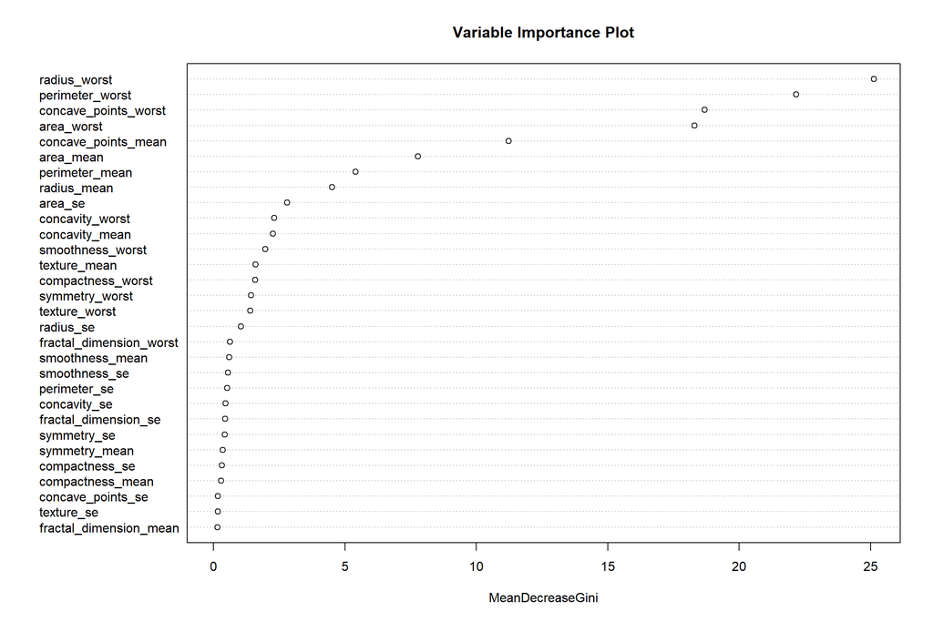

```r
# -------------------------------------------------------RANDOM FOREST ALGORITHM


# Build the best random forest model based on the best_forest_parameters
best_random_forest <- randomForest(diagnosis ~ ., data = breast_data_train_forest,
                                   nodesize = best_forest_parameters$nodesize,
                                   sampsize = best_forest_parameters$sampsize,
                                   mtry = best_forest_parameters$mtry,
                                   ntree = best_forest_parameters$ntree)

# Plot variable importance
varImpPlot(best_random_forest, main = "Variable Importance Plot")
```

```r
# Make predictions with the random forest model
rf_predictions <- predict(best_random_forest, newdata = breast_data_validation_forest)

# Create cross table
cross_table_rf <- CrossTable(x = breast_data_validation_forest$diagnosis,
                             y = rf_predictions,
                             prop.chisq = FALSE)
```

```
##
##
##    Cell Contents
## |-------------------------|
## |                       N |
## |           N / Row Total |
## |           N / Col Total |
## |         N / Table Total |
## |-------------------------|
##
##
## Total Observations in Table:  54
##
##
##                                         | rf_predictions
## breast_data_validation_forest$diagnosis |    Benign | Malignant | Row Total |
## ----------------------------------------|-----------|-----------|-----------|
##                                  Benign |        28 |         3 |        31 |
##                                         |     0.903 |     0.097 |     0.574 |
##                                         |     1.000 |     0.115 |           |
##                                         |     0.519 |     0.056 |           |
## ----------------------------------------|-----------|-----------|-----------|
##                               Malignant |         0 |        23 |        23 |
##                                         |     0.000 |     1.000 |     0.426 |
##                                         |     0.000 |     0.885 |           |
##                                         |     0.000 |     0.426 |           |
## ----------------------------------------|-----------|-----------|-----------|
##                            Column Total |        28 |        26 |        54 |
##                                         |     0.519 |     0.481 |           |
## ----------------------------------------|-----------|-----------|-----------|
##
##
```

```r
#printing the best parameters for the random forest model

cat("Best Forest Parameters:\n")
```

```
## Best Forest Parameters:
```

```r
cat("Nodesize:", best_forest_parameters$nodesize, "\n")
```

```
## Nodesize: 7
```

```r
cat("Sampsize:", best_forest_parameters$sampsize, "\n")
```

```
## Sampsize: 313
```

```r
cat("Mtry:", best_forest_parameters$mtry, "\n")
```

```
## Mtry: 9
```

```r
cat("Ntree:", best_forest_parameters$ntree, "\n")
```

```
## Ntree: 326
```

## 2.5. Logistic Regression algorithm

We create the training, testing and validation datasets for the Logistic Regression algorithm. They are exactly the same datasets as the training, validation and test datasets previously generated, but with its name adapted to this section.

```r
# --------------------------TRAIN & TEST LOGISTIC REGRESSION DATASET PREPARATION

breast_data_train_logistic <- breast_data_train_complete
breast_data_test_logistic <- breast_data_test_complete
breast_data_validation_logistic <- breast_data_validation_complete
```

Now, we use the dataset without the highly correlated variables.

```r
# ------------------------------------------CHECKING HIGHLY CORRELATED VARIABLES

breast_data_wo_highlyCor_train_logistic <- breast_data_train_logistic
breast_data_wo_highlyCor_train_logistic <- breast_data_wo_highlyCor_train_logistic[, -which(colnames(breast_data_wo_highlyCor_train_logistic) %in% highlyCorCol)]
breast_data_wo_highlyCor_train_logistic %>% head(5)
```

```
##          diagnosis texture_mean area_mean texture_se smoothness_se symmetry_se
## 842302   Malignant    0.0226581 0.3640416  0.1658452     0.1311176  0.31164518
## 84300903 Malignant    0.3902604 0.4497983  0.1298223     0.1223694  0.20569032
## 843786   Malignant    0.2025702 0.1416260  0.1612511     0.1701507  0.19372995
## 844359   Malignant    0.3473115 0.3805986  0.1256541     0.0578646  0.08172455
## 844981   Malignant    0.4095367 0.1597538  0.1952659     0.1076485  0.19063432
##          fractal_dimension_se smoothness_worst symmetry_worst
## 842302             0.18304244        0.5726919      0.7603306
## 84300903           0.12700551        0.4467634      0.5128976
## 843786             0.14465956        0.6922533      0.6060606
## 844359             0.04436660        0.4453484      0.3751565
## 844981             0.09860702        0.6299965      0.7044828
##          fractal_dimension_worst
## 842302                 0.4188640
## 84300903               0.2134330
## 843786                 0.4549390
## 844359                 0.1878526
## 844981                 0.3421225
```

We generate the logistic regression model with the breast cancer dataset without the highly correlated variables.

```r
# -----------------------------------------------------LOGISTIC REGRESSION MODEL

logistic_model <- glm(formula = diagnosis ~ ., data = breast_data_wo_highlyCor_train_logistic, family = binomial() )
summary (logistic_model)
```

```
##
## Call:
## glm(formula = diagnosis ~ ., family = binomial(), data = breast_data_wo_highlyCor_train_logistic)
##
## Coefficients:
##                         Estimate Std. Error z value Pr(>|z|)
## (Intercept)              -20.506      2.966  -6.913 4.73e-12 ***
## texture_mean               8.597      2.648   3.246  0.00117 **
## area_mean                 48.858      7.542   6.478 9.28e-11 ***
## texture_se                 2.888      2.899   0.996  0.31908
## smoothness_se              7.188      5.530   1.300  0.19369
## symmetry_se               -4.584      6.160  -0.744  0.45675
## fractal_dimension_se     -26.551     13.503  -1.966  0.04926 *
## smoothness_worst           7.407      4.381   1.691  0.09090 .
## symmetry_worst             5.365      4.444   1.207  0.22736
## fractal_dimension_worst   18.554      9.384   1.977  0.04803 *
## ---
## Signif. codes:  0 '***' 0.001 '**' 0.01 '*' 0.05 '.' 0.1 ' ' 1
##
## (Dispersion parameter for binomial family taken to be 1)
##
##     Null deviance: 498.863  on 387  degrees of freedom
## Residual deviance:  75.856  on 378  degrees of freedom
## AIC: 95.856
##
## Number of Fisher Scoring iterations: 9
```

```r
vif(logistic_model)
```

```
##            texture_mean               area_mean              texture_se
##                1.814824                3.130474                2.060236
##           smoothness_se             symmetry_se    fractal_dimension_se
##                5.782254                3.244534                9.907634
##        smoothness_worst          symmetry_worst fractal_dimension_worst
##                5.577022                4.334586               11.657576
```

We can’t see it here, but previously we generated this model without extracting the highly correlated variables, and the VIF results that we got were too large compared to what they should be (if they are higher than 5, they are considered highly correlated, but we got values in the order of thousands).

```r
# ------------------------------------------EVALUATION LOGISTIC REGRESSION MODEL

# Predictions on test data
logistic_predictions <- predict(logistic_model, newdata = breast_data_test_logistic, type = "response")
logistic_predictions_binary <- ifelse(logistic_predictions > 0.5, "Malignant", "Benign")

# Confusion matrix
conf_matrix <- table(Actual = breast_data_test_labels, Predicted = logistic_predictions_binary)

# Calculate accuracy
accuracy <- sum(diag(conf_matrix)) / sum(conf_matrix)

CrossTable(x = breast_data_test_labels, y = logistic_predictions_binary, prop.chisq = FALSE)
```

```
##
##
##    Cell Contents
## |-------------------------|
## |                       N |
## |           N / Row Total |
## |           N / Col Total |
## |         N / Table Total |
## |-------------------------|
##
##
## Total Observations in Table:  126
##
##
##                         | logistic_predictions_binary
## breast_data_test_labels |    Benign | Malignant | Row Total |
## ------------------------|-----------|-----------|-----------|
##                  Benign |        63 |         7 |        70 |
##                         |     0.900 |     0.100 |     0.556 |
##                         |     0.969 |     0.115 |           |
##                         |     0.500 |     0.056 |           |
## ------------------------|-----------|-----------|-----------|
##               Malignant |         2 |        54 |        56 |
##                         |     0.036 |     0.964 |     0.444 |
##                         |     0.031 |     0.885 |           |
##                         |     0.016 |     0.429 |           |
## ------------------------|-----------|-----------|-----------|
##            Column Total |        65 |        61 |       126 |
##                         |     0.516 |     0.484 |           |
## ------------------------|-----------|-----------|-----------|
##
##
```

```r
cat("Accuracy: ", round(accuracy, 3), "\n")
```

```
## Accuracy:  0.929
```

## 2.6. Algorithm comparison

#### Which of all models performs better for this data? Discuss.

#### Generate a ROC curve for all the models.

Looking at the cross tables and at the following ROC curves for each algorithm, we can conclude that the best trained model is the logistic regression. It has a area under the curve of 98,9%. But the other algorithms were quite good too, because all of them got values of the area under the curve above 95%.

##### KNN

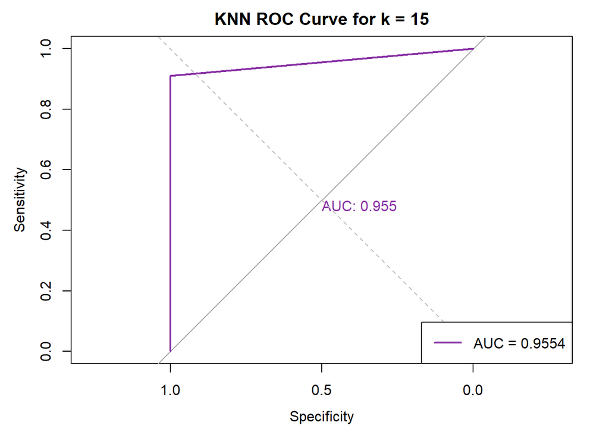

```r
# -----------------------------------------------------------------KNN ROC CURVE

ROC_Knn <- roc(as.numeric(breast_data_test_knn$diagnosis), as.numeric(best_knn_prediction))
plot(ROC_Knn, main = paste("KNN ROC Curve for k =", best_k), col = color1, percent = TRUE, plot = TRUE, print.auc = TRUE)

abline(a = 0, b = 1, lty = 2, col = "gray")  # Diagonal line
legend("bottomright", legend = paste("AUC =", round(auc(ROC_Knn), 4)), col = color1, lwd = 2)
```

##### DECISION TREE ROC CURVE

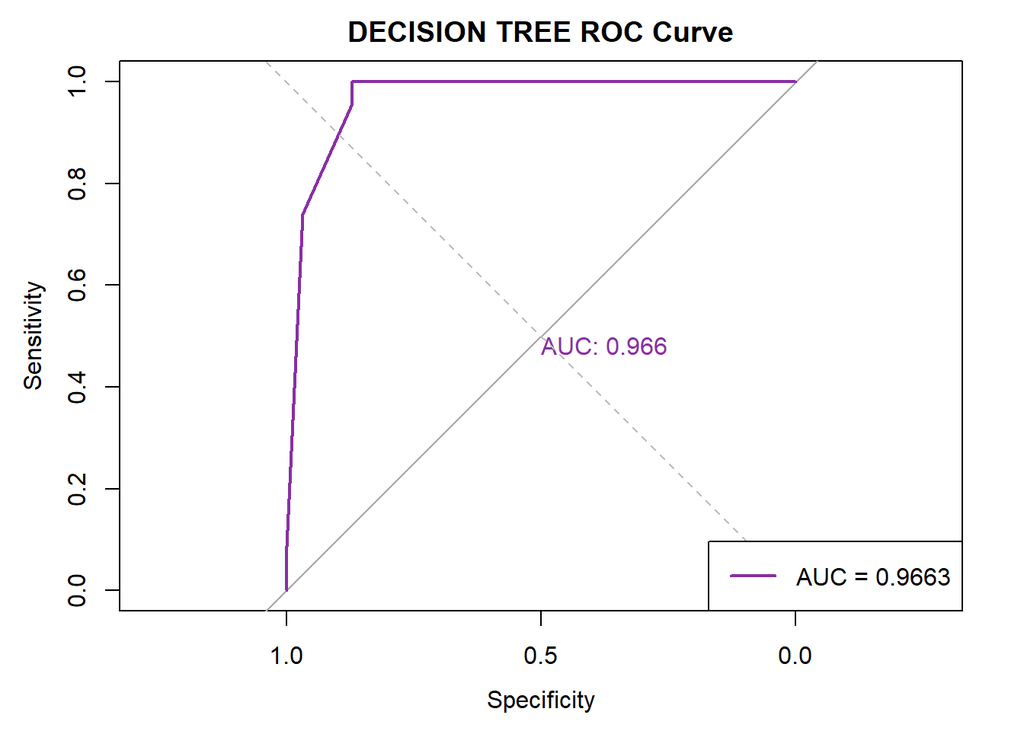

```r
# -------------------------------------------------------DECISION TREE ROC CURVE
ROC_Tree <- predict(final_decision_tree, breast_data_validation_tree)

ROC_Tree_plot <- roc(breast_data_validation_tree$diagnosis, main = paste("DECISION TREE ROC Curve"), col = color1, ROC_Tree[, 2], percent = FALSE, plot = TRUE, print.auc = TRUE)
abline(a = 0, b = 1, lty = 2, col = "gray")  # Diagonal line
legend("bottomright", legend = paste("AUC =", round(auc(ROC_Tree_plot), 4)), col = color1, lwd = 2)
```

##### RANDOM FOREST ROC CURVE

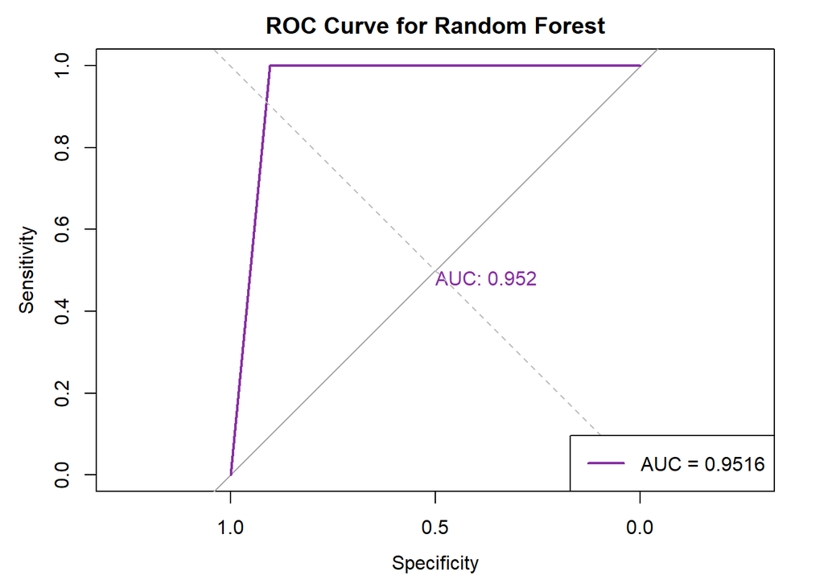

```r
# -------------------------------------------------------RANDOM FOREST ROC CURVE

ROC_Forest <- roc(as.numeric(breast_data_validation_forest$diagnosis), as.numeric(rf_predictions))
plot(ROC_Forest, main = "ROC Curve for Random Forest", col = color1, lwd = 2, percent = FALSE, plot = TRUE, print.auc = TRUE)

abline(a = 0, b = 1, lty = 2, col = "gray")

legend("bottomright", legend = paste("AUC =", round(auc(ROC_Forest), 4)), col = color1, lwd = 2)
```

##### LOGISTIC REGRESSION ROC CURVE

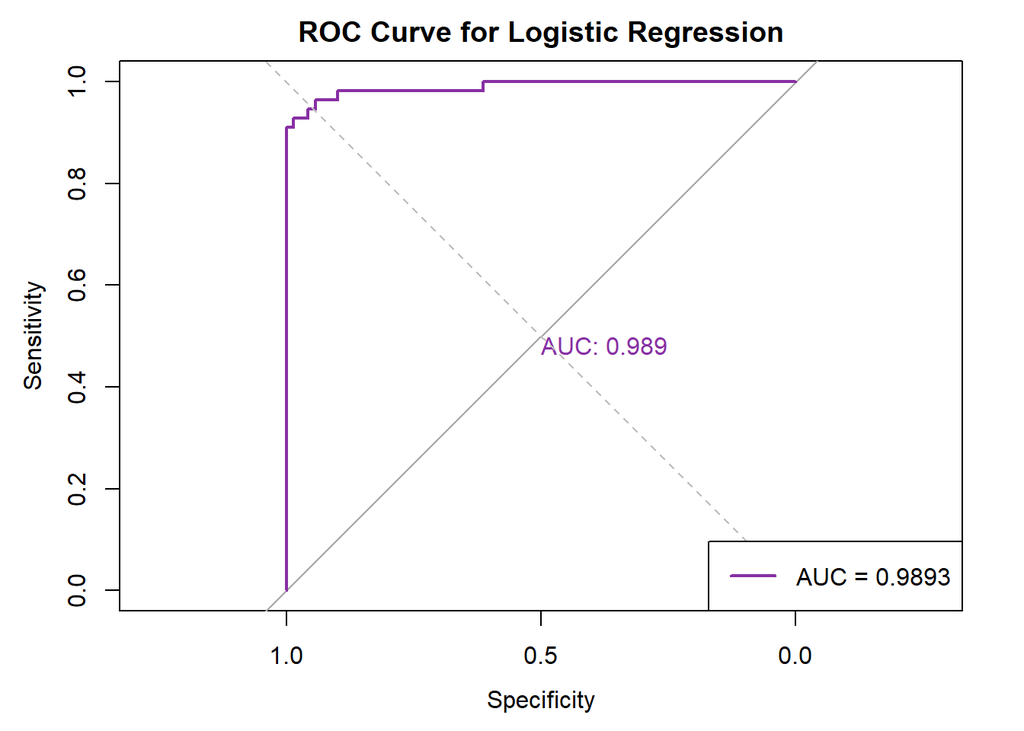

```r
# -------------------------------------------------LOGISTIC REGRESSION ROC CURVE

ROC_Logistic <- roc(as.numeric(breast_data_test_labels == "Malignant"), as.numeric(logistic_predictions))
plot(ROC_Logistic, main = "ROC Curve for Logistic Regression", col = color1, lwd = 2, percent = FALSE, plot = TRUE, print.auc = TRUE)

abline(a = 0, b = 1, lty = 2, col = "gray")

legend("bottomright", legend = paste("AUC =", round(auc(ROC_Logistic), 4)), col = color1, lwd = 2)
```

# 3. Exercise 3

## 3.1. Data preparation

We upload our datasets for each type of cancer, and delete the rows without information (from 1 to 4).  
Additionally we use the `str()` function to display the data type and structure of each column of the datasets.

```r
# ---------------------------------------------------TCGA-BLCA DATASET UPLOADING

TCGA_BLCA_data <- read_delim("./data/TCGA_data/BLCA/TCGA_BLCA_data.tsv", delim = "\t", escape_double = FALSE, show_col_types = FALSE, trim_ws = TRUE)

TCGA_BLCA_data <- as.data.frame(TCGA_BLCA_data)

TCGA_BLCA_data <- TCGA_BLCA_data[-c(1:4), ]

TCGA_BLCA_data <- TCGA_BLCA_data %>% mutate(gene_id = paste("BLCA_", gene_id, sep = ""))

str(TCGA_BLCA_data)
```

```
## 'data.frame':    3032902 obs. of  9 variables:
##  $ gene_id           : chr  "BLCA_ENSG00000000003.15" "BLCA_ENSG00000000005.6" "BLCA_ENSG00000000419.13" "BLCA_ENSG00000000457.14" ...
##  $ gene_name         : chr  "TSPAN6" "TNMD" "DPM1" "SCYL3" ...
##  $ gene_type         : chr  "protein_coding" "protein_coding" "protein_coding" "protein_coding" ...
##  $ unstranded        : num  1231 0 2391 1026 3498 ...
##  $ stranded_first    : num  594 0 1215 1703 2957 ...
##  $ stranded_second   : num  637 0 1176 1749 3083 ...
##  $ tpm_unstranded    : num  23.4 0 170.5 12.8 50.4 ...
##  $ fpkm_unstranded   : num  6.83 0 49.86 3.75 14.75 ...
##  $ fpkm_uq_unstranded: num  6.64 0 48.46 3.65 14.33 ...
```

```r
# ----------------------------------------------------TCGA-LGG DATASET UPLOADING

TCGA_LGG_data <- read_delim("./data/TCGA_data/LGG/TCGA_LGG_data.tsv", delim = "\t", escape_double = FALSE, show_col_types = FALSE, trim_ws = TRUE)

TCGA_LGG_data <- as.data.frame(TCGA_LGG_data)

TCGA_LGG_data <- TCGA_LGG_data[-c(1:4), ]

TCGA_LGG_data <- TCGA_LGG_data %>% mutate(gene_id = paste("LGG_", gene_id, sep = ""))

str(TCGA_LGG_data)
```

```
## 'data.frame':    3032902 obs. of  9 variables:
##  $ gene_id           : chr  "LGG_ENSG00000000003.15" "LGG_ENSG00000000005.6" "LGG_ENSG00000000419.13" "LGG_ENSG00000000457.14" ...
##  $ gene_name         : chr  "TSPAN6" "TNMD" "DPM1" "SCYL3" ...
##  $ gene_type         : chr  "protein_coding" "protein_coding" "protein_coding" "protein_coding" ...
##  $ unstranded        : num  5358 5 972 452 167 ...
##  $ stranded_first    : num  2743 1 487 421 283 ...
##  $ stranded_second   : num  2615 4 485 434 311 ...
##  $ tpm_unstranded    : num  100.26 0.287 68.353 5.574 2.374 ...
##  $ fpkm_unstranded   : num  28.2775 0.0811 19.2784 1.5721 0.6697 ...
##  $ fpkm_uq_unstranded: num  30.384 0.0871 20.7145 1.6892 0.7195 ...
```

We merge both datasets.

```r
# -----------------------------------------------------TCGA-BLCA DATASET MERGING

TCGA_data <- bind_rows(
  mutate(TCGA_BLCA_data, Tissue_Type = "BLCA"),
  mutate(TCGA_LGG_data, Tissue_Type = "LGG")
)
```

We remove rows that had the same `gene_id` (duplicates), and use the `gene_id` values as rownames.

```r
# --------------------------------------------------------TCGA DATASET MODIFYING

TCGA_data <- TCGA_data %>%
  distinct(gene_id, .keep_all = TRUE)

rownames(TCGA_data) <- TCGA_data$gene_id
TCGA_data <- TCGA_data[, -which(names(TCGA_data) == "gene_id")]

str(TCGA_data)
```

```
## 'data.frame':    121320 obs. of  9 variables:
##  $ gene_name         : chr  "TSPAN6" "TNMD" "DPM1" "SCYL3" ...
##  $ gene_type         : chr  "protein_coding" "protein_coding" "protein_coding" "protein_coding" ...
##  $ unstranded        : num  1231 0 2391 1026 3498 ...
##  $ stranded_first    : num  594 0 1215 1703 2957 ...
##  $ stranded_second   : num  637 0 1176 1749 3083 ...
##  $ tpm_unstranded    : num  23.4 0 170.5 12.8 50.4 ...
##  $ fpkm_unstranded   : num  6.83 0 49.86 3.75 14.75 ...
##  $ fpkm_uq_unstranded: num  6.64 0 48.46 3.65 14.33 ...
##  $ Tissue_Type       : chr  "BLCA" "BLCA" "BLCA" "BLCA" ...
```

## 3.2. Model

```r
# -----------------------------TRAIN, TEST & VALIDATION TCGA DATASET PREPARATION

# The following command sets the seed for the random number generator to ensure reproducibility.
set.seed(123)

# Generate a TRUE/FALSE vector for validation set
sample_TCGA_validation <- sample(c(TRUE, FALSE), size = nrow(TCGA_data), replace = TRUE, prob = c(0.10, 0.90))
TCGA_data_validation <- TCGA_data[sample_TCGA_validation,]

# The remaining data is used for training and testing
TCGA_data_test_training <- TCGA_data[!sample_TCGA_validation,]


#It is generated a TRUE/FALSE vector in order to split the dataset into train and test samples.
sample_TCGA <- sample(c(TRUE, FALSE), size = nrow(TCGA_data_test_training), replace = TRUE, prob = c(0.25, 0.75))
TCGA_data_train <- TCGA_data_test_training[!sample_TCGA,]
TCGA_data_test <- TCGA_data_test_training[sample_TCGA,]
```

Then, we normalize the numeric data of the dataset.

```r
# ---------------------------------------------------------NORMALIZING TCGA DATA

normalize <- function(x) {
return ((x - min(x)) / (max(x) - min(x)))}   #creating a normalize() function

TCGA_data_train_norm <- as.data.frame(lapply(TCGA_data_train[3:8], normalize))
rownames(TCGA_data_train_norm) <- rownames(TCGA_data_train)

TCGA_data_test_norm <- as.data.frame(lapply(TCGA_data_test[3:8], normalize))
rownames(TCGA_data_test_norm) <- rownames(TCGA_data_test)

TCGA_data_validation_norm <- as.data.frame(lapply(TCGA_data_validation[3:8], normalize))
rownames(TCGA_data_validation_norm) <- rownames(TCGA_data_validation)
```

```r
# ---------------------------REINTRODUCTION OF TEXT COLS TO NORMALIZED TCGA DATA

TCGA_data_train_complete <- cbind(TCGA_data_train$Tissue_Type, TCGA_data_train$gene_name, TCGA_data_train$gene_type, TCGA_data_train_norm)
colnames(TCGA_data_train_complete)[1] <- "tissue_type"
colnames(TCGA_data_train_complete)[2] <- "gene_name"
colnames(TCGA_data_train_complete)[3] <- "gene_type"

TCGA_data_test_complete <- cbind(TCGA_data_test$Tissue_Type, TCGA_data_test$gene_name, TCGA_data_test$gene_type, TCGA_data_test_norm)
colnames(TCGA_data_test_complete)[1] <- "tissue_type"
colnames(TCGA_data_test_complete)[2] <- "gene_name"
colnames(TCGA_data_test_complete)[3] <- "gene_type"

TCGA_data_validation_complete <- cbind(TCGA_data_validation$Tissue_Type, TCGA_data_validation$gene_name, TCGA_data_validation$gene_type, TCGA_data_validation_norm)
colnames(TCGA_data_validation_complete)[1] <- "tissue_type"
colnames(TCGA_data_validation_complete)[2] <- "gene_name"
colnames(TCGA_data_validation_complete)[3] <- "gene_type"
```

```r
# ------------------------------------------CHECKING HIGHLY CORRELATED VARIABLES

TCGA_data_train_WO_genename_genetype <- TCGA_data_train_complete %>% select(-gene_name, -gene_type)
TCGA_multicollinearity <- subset (TCGA_data_train_WO_genename_genetype, select = -c(tissue_type))
TCGA_multicollinearity_cor <- cor(TCGA_multicollinearity)

TCGA_highlyCorrelated = findCorrelation(TCGA_multicollinearity_cor, cutoff=0.7)
TCGA_highlyCorCol = colnames(TCGA_multicollinearity) [TCGA_highlyCorrelated]
TCGA_highlyCorCol
```

```
## [1] "fpkm_uq_unstranded" "stranded_first"     "unstranded"
## [4] "fpkm_unstranded"
```

```r
TCGA_data_wo_highlyCor_train <- TCGA_data_train_WO_genename_genetype
TCGA_data_wo_highlyCor_train <- TCGA_data_wo_highlyCor_train[, -which(colnames(TCGA_data_wo_highlyCor_train) %in% TCGA_highlyCorCol)]

TCGA_data_wo_highlyCor_train %>% head(5)
```

```
##                         tissue_type stranded_second tpm_unstranded
## BLCA_ENSG00000000003.15        BLCA    5.876904e-04   6.245135e-04
## BLCA_ENSG00000000005.6         BLCA    0.000000e+00   0.000000e+00
## BLCA_ENSG00000000419.13        BLCA    1.084967e-03   4.558577e-03
## BLCA_ENSG00000000457.14        BLCA    1.613612e-03   3.430245e-04
## BLCA_ENSG00000000938.13        BLCA    5.351027e-05   9.117791e-05
```

Then, because in the exercise 2 we got the best results with the logistic regression algorithm, we decided to use it in this case.  
So, we performed the logistic regression model.

```r
# -----------------------------------------FITTING THE LOGISTIC REGRESSION MODEL

TCGA_data_train_WO_genename_genetype$tissue_type <- factor(TCGA_data_train_WO_genename_genetype$tissue_type)

# Fit logistic regression model
TCGA_logistic_model <- glm(formula = tissue_type ~ ., data = TCGA_data_train_WO_genename_genetype, family = binomial())

# Display summary of the model
summary(TCGA_logistic_model)
```

```
##
## Call:
## glm(formula = tissue_type ~ ., family = binomial(), data = TCGA_data_train_WO_genename_genetype)
##
## Coefficients:
##                      Estimate Std. Error z value Pr(>|z|)
## (Intercept)        -1.085e-01  1.001e-02 -10.835  < 2e-16 ***
## unstranded         -3.034e+05  4.804e+05  -0.632   0.5276
## stranded_first      4.670e+01  7.802e+02   0.060   0.9523
## stranded_second    -4.928e+01  7.520e+02  -0.066   0.9477
## tpm_unstranded     -9.262e+08  4.279e+08  -2.164   0.0304 *
## fpkm_unstranded    -7.405e+07  2.407e+08  -0.308   0.7583
## fpkm_uq_unstranded  1.032e+09  2.379e+08   4.340 1.42e-05 ***
## ---
## Signif. codes:  0 '***' 0.001 '**' 0.01 '*' 0.05 '.' 0.1 ' ' 1
##
## (Dispersion parameter for binomial family taken to be 1)
##
##     Null deviance: 113543  on 81903  degrees of freedom
## Residual deviance:  55420  on 81897  degrees of freedom
## AIC: 55434
##
## Number of Fisher Scoring iterations: 25
```

```r
# Check for multicollinearity using the vif function
vif(TCGA_logistic_model)
```

```
##         unstranded     stranded_first    stranded_second     tpm_unstranded
##           1.297173         659.954972         659.954960       15435.863734
##    fpkm_unstranded fpkm_uq_unstranded
##        5047.339344        4503.134910
```

The p-values indicate the significance of each predictor variable. A smaller p-value (<0.05) suggests that the predictor is associated with the response variable. The “fpkm_uq_unstranded” predictor variable appears highly statistically significant.  
We fitted the logistic regression model, but only using the variables `fpkm_uq_unstranded` and `tpm_unstranded`, because no relation was found in the rest.

```r
# --------FITTING THE LOGISTIC REGRESSION MODEL ONLY WITH SIGNIFICANT PREDICTORS

# Fit logistic regression model with significant predictors
selected_model <- glm(formula = tissue_type ~ fpkm_uq_unstranded + tpm_unstranded,
                       family = binomial(),
                       data = TCGA_data_train_WO_genename_genetype)
# Display summary of the selected model
summary(selected_model)
```

```
##
## Call:
## glm(formula = tissue_type ~ fpkm_uq_unstranded + tpm_unstranded,
##     family = binomial(), data = TCGA_data_train_WO_genename_genetype)
##
## Coefficients:
##                      Estimate Std. Error z value Pr(>|z|)
## (Intercept)        -1.086e-01  1.001e-02 -10.848  < 2e-16 ***
## fpkm_uq_unstranded  1.100e+09  1.934e+08   5.687 1.29e-08 ***
## tpm_unstranded     -1.068e+09  1.878e+08  -5.686 1.30e-08 ***
## ---
## Signif. codes:  0 '***' 0.001 '**' 0.01 '*' 0.05 '.' 0.1 ' ' 1
##
## (Dispersion parameter for binomial family taken to be 1)
##
##     Null deviance: 113543  on 81903  degrees of freedom
## Residual deviance:  55420  on 81901  degrees of freedom
## AIC: 55426
##
## Number of Fisher Scoring iterations: 25
```

Finally, we perform an evaluation of the last model.

```r
# ------------------------------------------EVALUATION LOGISTIC REGRESSION MODEL

# Predictions on test data
TCGA_logistic_predictions <- predict(selected_model, newdata = TCGA_data_test_complete, type = "response")
TCGA_logistic_predictions_binary <- ifelse(TCGA_logistic_predictions > 0.5, "LGG", "BLCA")

# Confusion matrix
TCGA_conf_matrix <- table(Actual = TCGA_data_test_complete$tissue_type, Predicted = TCGA_logistic_predictions_binary)

# Calculate accuracy
accuracy <- sum(diag(TCGA_conf_matrix)) / sum(TCGA_conf_matrix)

CrossTable(x = TCGA_data_test_complete$tissue_type, y = TCGA_logistic_predictions_binary, prop.chisq = FALSE)
```

```
##
##
##    Cell Contents
## |-------------------------|
## |                       N |
## |           N / Row Total |
## |           N / Col Total |
## |         N / Table Total |
## |-------------------------|
##
##
## Total Observations in Table:  27249
##
##
##                                     | TCGA_logistic_predictions_binary
## TCGA_data_test_complete$tissue_type |      BLCA |       LGG | Row Total |
## ------------------------------------|-----------|-----------|-----------|
##                                BLCA |     13766 |         0 |     13766 |
##                                     |     1.000 |     0.000 |     0.505 |
##                                     |     0.684 |     0.000 |           |
##                                     |     0.505 |     0.000 |           |
## ------------------------------------|-----------|-----------|-----------|
##                                 LGG |      6366 |      7117 |     13483 |
##                                     |     0.472 |     0.528 |     0.495 |
##                                     |     0.316 |     1.000 |           |
##                                     |     0.234 |     0.261 |           |
## ------------------------------------|-----------|-----------|-----------|
##                        Column Total |     20132 |      7117 |     27249 |
##                                     |     0.739 |     0.261 |           |
## ------------------------------------|-----------|-----------|-----------|
##
##
```

```r
cat("Accuracy:", round(accuracy, 3), "\n")
```

```
## Accuracy: 0.766
```

And generated a ROC curve.

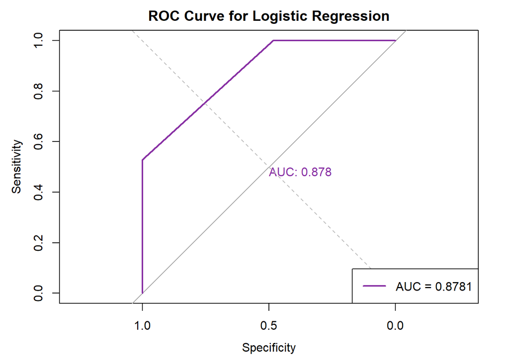

```r
# ------------------------------------------------------LOGISTIC MODEL ROC CURVE

ROC_Logistic <- roc(as.numeric(TCGA_data_test_complete$tissue_type == "LGG"), as.numeric(TCGA_logistic_predictions))
plot(ROC_Logistic, main = "ROC Curve for Logistic Regression", col = color1, lwd = 2, percent = FALSE, plot = TRUE, print.auc = TRUE)

abline(a = 0, b = 1, lty = 2, col = "gray")

legend("bottomright", legend = paste("AUC =", round(auc(ROC_Logistic), 4)), col = color1, lwd = 2)
```

The model AUC obtained is 0.878, which indicates that the logistic regression model has a good discriminatory ability. With AUC of 0.878, the model is demonstrating a strong ability to discriminate between the classses.

# Session info

R version 4.3.2 (2023-10-31 ucrt) Platform: x86_64-w64-mingw32/x64 (64-bit) Running under: Windows 10 x64 (build 19045)

Matrix products: default

locale: [1] LC_COLLATE=Spanish_Spain.utf8 LC_CTYPE=Spanish_Spain.utf8  
[3] LC_MONETARY=Spanish_Spain.utf8 LC_NUMERIC=C  
[5] LC_TIME=Spanish_Spain.utf8

time zone: Europe/Madrid tzcode source: internal

attached base packages: [1] stats graphics grDevices utils datasets methods base

other attached packages: [1] glmnet_4.1-8 Matrix_1.6-5 ggcorrplot_0.1.4.1  
[4] caret_6.0-94 lattice_0.22-5 randomForest_4.7-1.1 [7] pROC_1.18.5 rpart.plot_3.1.2 rpart_4.1.23  
[10] gmodels_2.18.1.1 class_7.3-22 corrplot_0.92  
[13] yardstick_1.3.0 workflowsets_1.0.1 workflows_1.1.4  
[16] tune_1.1.2 tidyr_1.3.1 tibble_3.2.1  
[19] rsample_1.2.0 recipes_1.0.10 purrr_1.0.2  
[22] parsnip_1.2.0 modeldata_1.3.0 infer_1.0.6  
[25] ggplot2_3.4.4 dials_1.2.1 scales_1.3.0  
[28] broom_1.0.5 tidymodels_1.1.1 leaps_3.1  
[31] car_3.1-2 carData_3.0-5 dplyr_1.1.4  
[34] readr_2.1.5

loaded via a namespace (and not attached): [1] rlang_1.1.3 magrittr_2.0.3 furrr_0.3.1  
[4] compiler_4.3.2 gdata_3.0.0 vctrs_0.6.5  
[7] reshape2_1.4.4 lhs_1.1.6 stringr_1.5.1  
[10] crayon_1.5.2 shape_1.4.6 pkgconfig_2.0.3  
[13] fastmap_1.1.1 backports_1.4.1 labeling_0.4.3  
[16] utf8_1.2.4 rmarkdown_2.25 prodlim_2023.08.28  
[19] tzdb_0.4.0 bit_4.0.5 xfun_0.42  
[22] cachem_1.0.8 jsonlite_1.8.8 highr_0.10  
[25] parallel_4.3.2 R6_2.5.1 stringi_1.8.3  
[28] bslib_0.6.1 parallelly_1.36.0 lubridate_1.9.3  
[31] jquerylib_0.1.4 Rcpp_1.0.12 iterators_1.0.14  
[34] knitr_1.45 future.apply_1.11.1 splines_4.3.2  
[37] nnet_7.3-19 timechange_0.3.0 tidyselect_1.2.0  
[40] rstudioapi_0.15.0 abind_1.4-5 yaml_2.3.8  
[43] timeDate_4032.109 codetools_0.2-19 listenv_0.9.1  
[46] plyr_1.8.9 withr_3.0.0 evaluate_0.23  
[49] future_1.33.1 survival_3.5-7 pillar_1.9.0  
[52] stats4_4.3.2 foreach_1.5.2 generics_0.1.3  
[55] vroom_1.6.5 hms_1.1.3 munsell_0.5.0  
[58] globals_0.16.2 gtools_3.9.5 glue_1.6.2  
[61] tools_4.3.2 data.table_1.15.0 ModelMetrics_1.2.2.2 [64] gower_1.0.1 grid_4.3.2 ipred_0.9-14  
[67] colorspace_2.1-0 nlme_3.1-164 cli_3.6.1  
[70] DiceDesign_1.10 fansi_1.0.5 lava_1.7.3  
[73] gtable_0.3.4 GPfit_1.0-8 sass_0.4.8  
[76] digest_0.6.34 farver_2.1.1 htmltools_0.5.7  
[79] lifecycle_1.0.4 hardhat_1.3.1 bit64_4.0.5  
[82] MASS_7.3-60.0.1